# Collinearity and PCA

4 Oct 2016

## Part 1

### Estimating regression parameters from correlated features

## Regression

We all know about least squares regression, we have a quantitative output and one ore more inputs. We would write the predicted value for case \(i\) when there are \(p\) features as:

\[ \hat{y_i} = \beta_0 + \Sigma_{j = 1}^{p} \beta_j x_{ij} \]

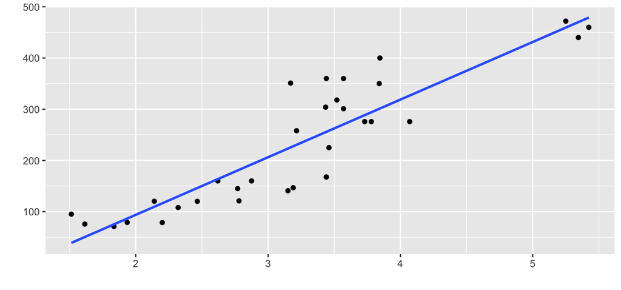

## Matrix notation

Since this is a linear combination of the inputs we can rewrite it conveniently or all cases to:

\[ \bf\hat{y} = \bf{X}\bf{\beta} \]

Where \(\bf\hat{y}\) is a vector with predictions, \(\bf{X}\) is a matrix with each row the observations of one case and each column the values of a feature (with columns of 1's), and \(\bf{\beta}\) a vector wiht weights.

## Least squares

The loss we want to minimize, is called the residual sum of squares of the estimates. In matrix notation it is:

\[ RSS(\bf{\beta}) = (\bf{y} - \bf{X}\bf{\beta})^T (\bf{y} - \bf{X}\bf{\beta}) \]

We want to minimize this for \(\bf{\beta}\), so we need to take the derivative w.r.t. \(\bf{\beta}\) and set it to 0.

This yields:

\[ \bf{\hat{\beta} = (X^TX)^{-1} X^Ty} \]

## Perfect multicollinearity

So we are looking for a \(p\)-dimensional hyperplane that minimizes the \(RSS\) for the \(p\) features w.r.t. \(\bf{y}\).

What would happen if we mistakingly put two versions of the same feature in the model?

\[ \bf{\hat{\beta} = (X^TX)^{-1} X^Ty} \]

## Perfect multicollinearity

```r
x <- mtcars %>% mutate(cyl2 = 2*cyl) %>%  select(mpg, cyl, cyl2)
lm(mpg ~ ., data = x)
```

```
##
## Call:
## lm(formula = mpg ~ ., data = x)
##
## Coefficients:
## (Intercept)          cyl         cyl2
##      37.885       -2.876           NA
```

`lm` removes perfectly correlated features, but if it didn't we were unable to find a solution.

## High correlation

We rarely have perfect multicollinearity (singular \(\bf{X}\) matrix), however often we do have many correlated features.

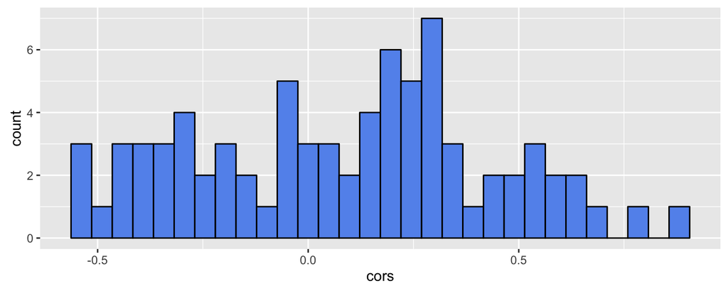

```r
wine_cor <- wine %>% select(-class) %>% cor %>% round(2)
data.frame(cors = wine_cor[upper.tri(wine_cor)]) %>%
  ggplot(aes(cors)) +
  geom_histogram(fill = 'cornflowerblue', col = 'black')
```

## High correlation

Although the parameters can be estimated, the correlations impact the estimates.

```r
set.seed(1234)
x1 <- rnorm(100)
x2 <- x1 + rnorm(100, 0, .5)
cor(x1, x2)
```

```
## [1] 0.8870524
```

```r
y <- x1 + x2 + rnorm(100)
```

## High correlation

```r
lm(y ~ x1, data.frame(x1, y))$coefficients
```

```
## (Intercept)          x1
##   0.1854411   2.0651680
```

```r
lm(y ~ x2, data.frame(x2, y))$coefficients
```

```
## (Intercept)          x2
##   0.1199954   1.8972628
```

```r
lm(y ~ ., data.frame(x1, x2, y))$coefficients
```

```
## (Intercept)          x1          x2
##   0.1635827   0.9038757   1.1766386
```

## Just take another sample

```r
set.seed(2345)
x1 <- rnorm(100)
x2 <- x1 + rnorm(100, 0, .5)
y <- x1 + x2 + rnorm(100)
lm(y ~ ., data.frame(x1, x2, y))$coefficients
```

```
## (Intercept)          x1          x2
## -0.03920709  1.43944614  0.62327110
```

We are going to explore this further in **Lab 1**.

## Results lab 1

[figure not shown]

## Part 2

### Feature interpretation

## Machine Learning

Effects can not bet disentangled. Does this matter?

- for prediction? No, as long as predictions are accurate.
- for interpretation? Yes, we can't report the individual effects.

Note that variance of the parameter estimates is different from variance in prediction function.

Former is thus caused by correlated features, latter by too few data points for the complexity we want to model.

## What if interpretation matters?

Just gathering lots of data points on many features in an algorithm might get the job done.

But often we are looking for understanding as well as accurate predictions:

- Leads to better models (what can we do to improve?)
- Better explanation to business
- Justification to outside world (regulators)
- Reduces algorithm-anxiety at customers

## How to get understanding?

We can get the variable importance explicitly from regularized regression, or implicitly with feature importance.

This is often what we report, but it only shows feature importance in the model.

Besides, we can look at univariate relationships between fearures and targets:

- linear: correlation, R sq. of univariate regression.
- nonlinear: correlation, R sq. of transformations, gini, prediction stats with ml methods.

## Wine example: boosting

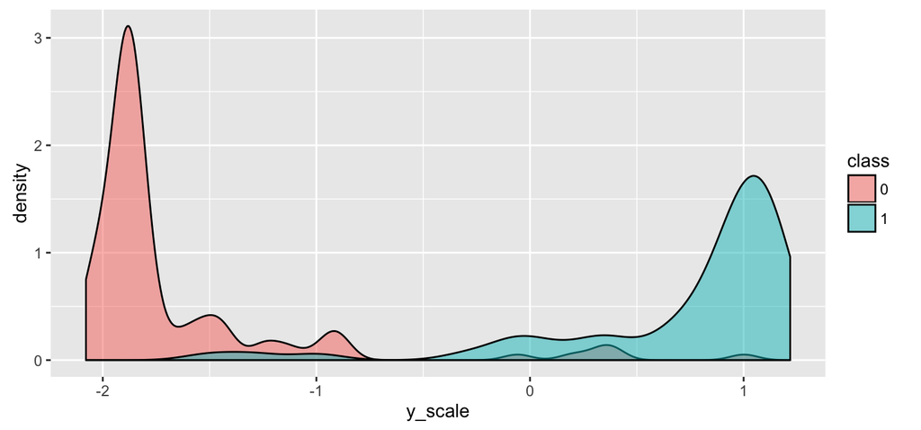

```r
wine <- read.csv('./wine.csv')
wine$class <- as.numeric(wine$class == 1)
boosted_tree <- gbm::gbm(class ~ ., data = wine, n.trees = 1000,
        interaction.depth = 2, cv.folds = 5, distribution = 'bernoulli')
data.frame(y_scale = boosted_tree$cv.fitted, class = factor(wine$class)) %>%
  ggplot(aes(y_scale)) + geom_density(aes(fill = class), alpha = .5)
```

## Relative information from `gbm`

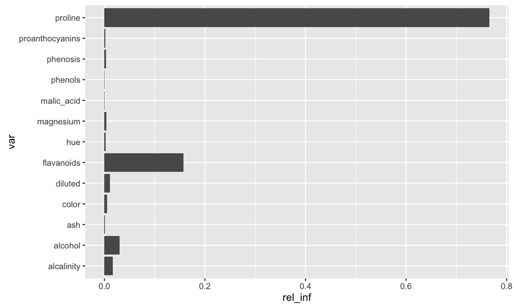

```r
load('./relative_information.Rdata')
ggplot(rel_inf, aes(var, rel_inf)) +
  geom_bar(stat = 'identity') + coord_flip()
```

## Univariate predictive value

```r
graphic_univariate <-
  gather(wine, feature, value, -class) %>%
  mutate(class = factor(class)) %>%
  group_by(feature) %>%
  mutate(z_value = scale(value)) %>%
  ggplot(aes(z_value)) +
  geom_density(aes(fill = class), alpha = 0.5) +
  facet_wrap(~feature, scale = 'free_y')
```

## Univariate predictive value

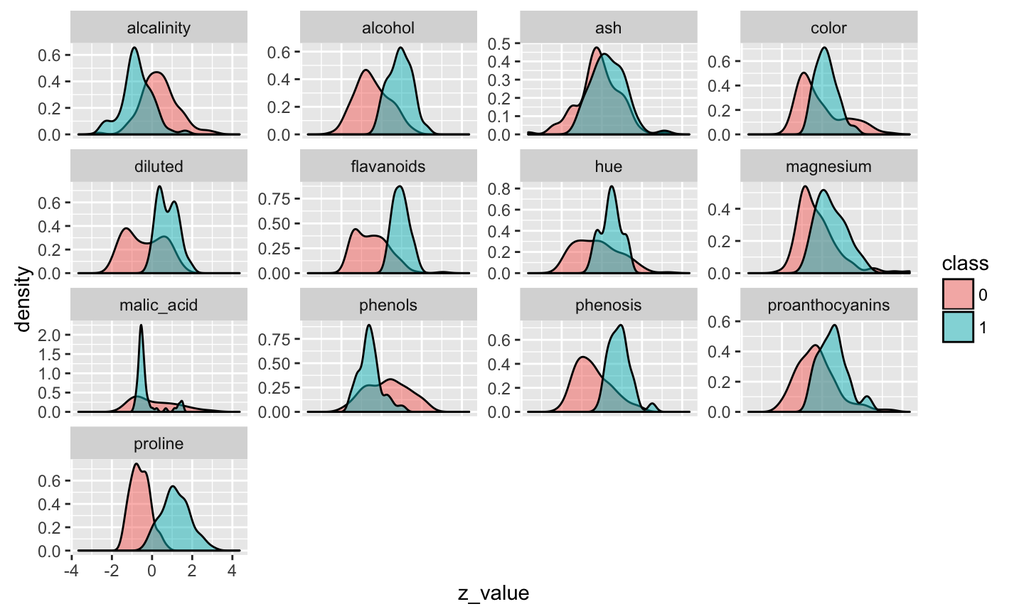

```r
graphic_univariate
```

## Correlation among features

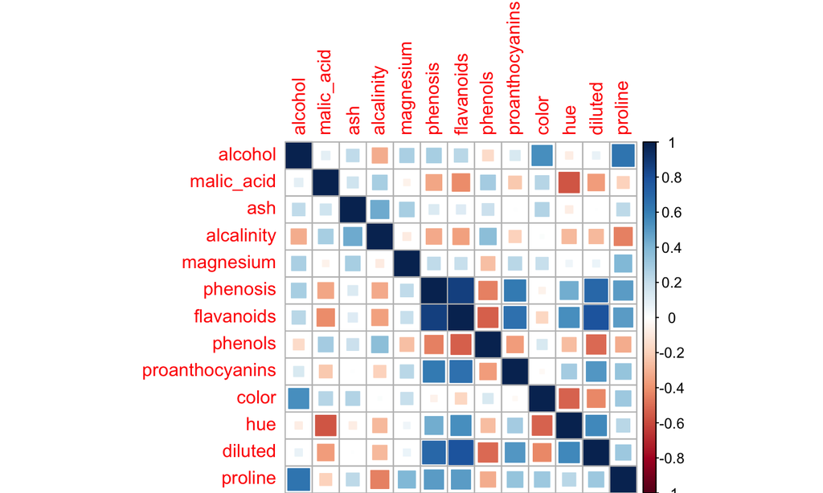

```r
library(corrplot); wine %>% select(-class) %>% cor %>% corrplot(method = 'square')
```

## Using a biplot to see which features obscures which

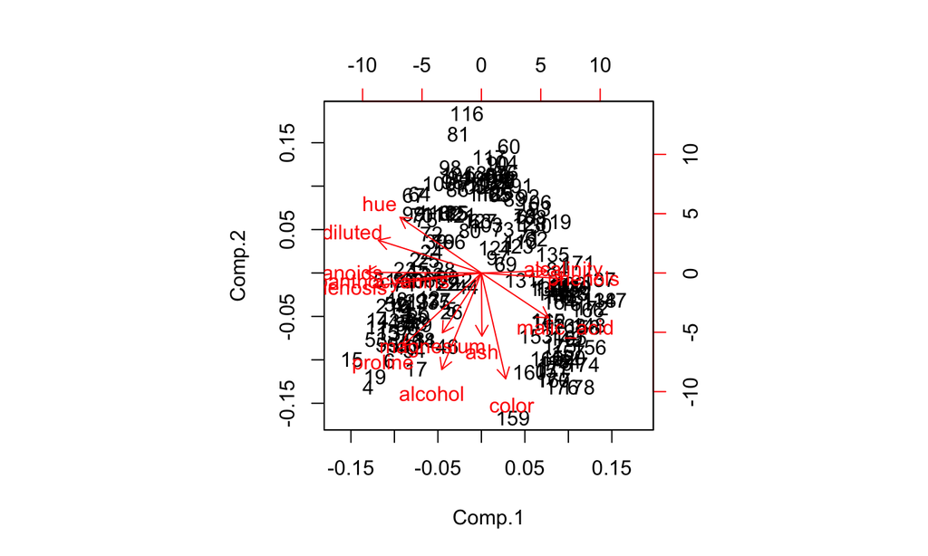

```r
princomp(wine %>% select(-class) %>% apply(2, scale)) %>% biplot
```